# 2 Del registro a la matriz: el problema geométrico

**NotaEn este capítulo**

**Pregunta.** ¿Qué matriz tengo y qué significa compararla?

**Objetivos.** Clasificar cada matriz que produce un análisis de EEG (hermítica definida positiva, real definida positiva, de correlación, semidefinida o indefinida), demostrar por qué unas viven en el cono $\SPD_n$ y otras no, y distinguir las transformaciones que respetan el cono de las que no. Formular las dos preguntas científicas que recorren el libro.

**Prerrequisitos.** Álgebra lineal y nociones de análisis espectral de señales. El registro y el preprocesado del EEG se dan por conocidos (libro de NeuroMIND).

**Código.** El laboratorio genera datos sintéticos con semilla fija. Las funciones de generación y de medidas de este capítulo son provisionales: cuando el paquete tenga el generador de la cohorte (apéndice D) pasarán a `NeuroRiemann.jl`.

## 2.1 La pregunta

Un EEG de $n$ canales no es una matriz: es una señal. Las matrices aparecen cuando se resume su estructura de segundo orden: cuánta potencia tiene cada canal y cómo se relacionan entre sí. La covarianza, la correlación, la coherencia, la coherencia imaginaria y el wPLI se calculan a partir del mismo objeto, el espectro cruzado, pero **no son el mismo tipo de matriz**. Unas son definidas positivas, otras solo semidefinidas, otras indefinidas por construcción; unas son reales y otras complejas. Antes de elegir una geometría para compararlas hay que saber qué objeto se tiene.

El libro persigue dos preguntas científicas, formuladas sobre una cohorte sintética (apéndice D):

1. **Transversal.** ¿Se diferencian las matrices de los pacientes con esclerosis múltiple (EM) de las de los controles?
2. **Longitudinal.** ¿Cambian las matrices de una persona entre dos visitas T1 y T2?

Las dos exigen **comparar matrices** (restarlas, promediarlas, medir su distancia), y para eso hay que saber en qué conjunto viven.

**TipReales y complejas**

Las covarianzas temporales son matrices reales simétricas (traspuesta $P^\top$, congruencia $WPW^\top$). Las matrices espectrales cruzadas son en general hermíticas (adjunta $P^*=\overline{P}^\top$, congruencia $WPW^*$) y conservan la fase. Este capítulo trabaja con las dos y las distingue siempre; el capítulo 4 se limita a las reales.

## 2.2 Del registro al espectro cruzado

Sea $x(t)\in\R^n$ el registro, ya preprocesado, dividido en $K$ segmentos (épocas). Para cada segmento $k$ y cada frecuencia $f$, sea $X_k(f)\in\mathbb C^n$ su transformada de Fourier con ventana. El **espectro cruzado estimado** es
$$\hat S(f)=\frac1K\sum_{k=1}^K X_k(f)\,X_k(f)^*\in\mathbb C^{n\times n}.
\tag{2.1}$$
La entrada $\hat S_{ij}=\tfrac1K\sum_kX_{k,i}\overline{X_{k,j}}$ mide cuánto se parecen los canales $i$ y $j$ en la frecuencia $f$ y con qué desfase.

**Teorema 2.1 (El espectro cruzado es hermítico semidefinido positivo)** Para todo $f$, $\hat S(f)$ es hermítica y semidefinida positiva, y $\operatorname{rango}\hat S\le\min(K,n)$. Es definida positiva si y solo si $\operatorname{rango}\hat S=n$, lo que exige $K\ge n$. Demostrado

*Demostración*. $\hat S^*=\hat S$ porque cada sumando $XX^*$ es hermítico. Para $v\in\mathbb C^n$, $v^*\hat Sv=\tfrac1K\sum_k|X_k^*v|^2\ge0$, con igualdad si y solo si $X_k^*v=0$ para todo $k$, es decir, si $v$ es ortogonal a los $K$ vectores $X_k$. Esos vectores generan un subespacio de dimensión a lo sumo $\min(K,n)$, así que el núcleo de $\hat S$ es trivial exactamente cuando generan $\mathbb C^n$.

La consecuencia práctica es inmediata: con pocos segmentos o con canales linealmente dependientes, $\hat S$ queda en la frontera del cono y las distancias que se estudian en el capítulo 4 no están definidas. El capítulo 3 trata ese caso.

### 2.2.1 Las matrices que salen del espectro

Todas las matrices del libro son proyecciones de $\hat S$. Sea $D=\operatorname{diag}(\hat S_{11},\dots,\hat S_{nn})$ y $\hat C=D^{-1/2}\hat SD^{-1/2}$ la **matriz de coherencia compleja** (de entradas $\hat C_{ij}$, la «coherency» de la literatura). Las medidas habituales son (Nolte et al. 2004; Vinck et al. 2011):

- **Coherencia:** $|\hat C_{ij}|$. **Coherencia imaginaria:** $|\operatorname{Im}\hat C_{ij}|$.
- **PLV:** $\mathrm{PLV}_{ij}=\Big|\tfrac1K\sum_k X^{ij}_k/|X^{ij}_k|\Big|$, con $X^{ij}_k=X_{k,i}\overline{X_{k,j}}$.
- **wPLI:** $\mathrm{wPLI}_{ij}=\dfrac{\big|\sum_k\operatorname{Im}X^{ij}_k\big|}{\sum_k\big|\operatorname{Im}X^{ij}_k\big|}$, con diagonal nula por convención.

La **covarianza de banda** se define como $C_B:=\sum_{f\in B}\operatorname{Re}\hat S(f)$, con la normalización que se declare en cada uso; coincide, salvo una constante, con la covarianza de la señal filtrada en la banda $B$ (identidad de Parseval) [VERIFICAR fuente].

**Proposición 2.1 (Parte real y parte imaginaria)** Sea $S\in\mathbb C^{n\times n}$ hermítica semidefinida positiva. Entonces $\operatorname{Re}S$ es simétrica semidefinida positiva y $\operatorname{Im}S$ es antisimétrica, con diagonal nula. Si $S$ es definida positiva, $\operatorname{Re}S$ es definida positiva. El recíproco es falso. Demostrado

*Demostración*. De $S^*=S$ se sigue $(\operatorname{Re}S)^\top-i(\operatorname{Im}S)^\top=\operatorname{Re}S+i\operatorname{Im}S$, es decir, $\operatorname{Re}S$ simétrica e $\operatorname{Im}S$ antisimétrica. Para $x\in\R^n$, $x^\top(\operatorname{Re}S)x=\operatorname{Re}(x^\top Sx)=x^*Sx\ge0$ (el último paso, porque $x^*Sx$ es real por ser $S$ hermítica), con desigualdad estricta si $S\succ0$ y $x\neq0$. Contraejemplo del recíproco: $S=\begin{pmatrix}1&i\\-i&1\end{pmatrix}$ es hermítica con autovalores $0$ y $2$, singular, mientras que $\operatorname{Re}S=I$.

**Proposición 2.2 (La coherencia compleja y la coherencia al cuadrado)** Si $\hat S$ es definida positiva, la matriz de coherencia compleja $\hat C$ es hermítica definida positiva con diagonal unitaria, y la matriz $\big(|\hat C_{ij}|^2\big)_{ij}$ es real simétrica definida positiva con diagonal unitaria. Demostrado

*Demostración*. $\hat C=D^{-1/2}\hat SD^{-1/2}$ es una congruencia de $\hat S$ por una matriz diagonal invertible, así que es hermítica definida positiva, y su diagonal es $1$ por construcción. Para la segunda afirmación, $\big(|\hat C_{ij}|^2\big)=\hat C\circ\overline{\hat C}$ (producto de Hadamard). Escribamos $\overline{\hat C}=\sum_lb_lb_l^*$ con los $b_l$ generando $\mathbb C^n$ (es definida positiva). Entonces $\hat C\circ\overline{\hat C}=\sum_l\operatorname{diag}(b_l)\,\hat C\,\operatorname{diag}(b_l)^*\succeq0$, y si $v^*(\hat C\circ\overline{\hat C})v=0$ cada $\operatorname{diag}(b_l)^*v=0$, lo que fuerza $v=0$ porque para cada índice $i$ algún $b_l$ tiene $b_l(i)\neq0$. Es real y simétrica porque $|\hat C_{ij}|^2=|\hat C_{ji}|^2$ (teorema del producto de Schur; véase también (Bhatia 2007, cap. 1)).

**Proposición 2.3 (El wPLI no vive en el cono)** Sea $W\in\R^{n\times n}$ simétrica con diagonal nula y $W\neq0$ (como el wPLI y la coherencia imaginaria en valor absoluto). Entonces $W$ tiene un autovalor negativo y otro positivo: es **indefinida**. Demostrado

*Demostración*. $\operatorname{tr}W=\sum_i\lambda_i=0$ por tener diagonal nula. Como $W$ es simétrica y no nula, algún autovalor es distinto de cero; como suman cero, hay uno positivo y otro negativo.

La Tabla 2.1 resume el panorama. Que una matriz sea semidefinida o indefinida **no es un defecto del análisis**: es lo que ocurre con esas medidas. Lo que cambia es qué geometría admite cada una, y esa es la pregunta que organiza el libro.

Tabla 2.1: Clasificación de las matrices que produce un análisis de EEG. «SPD» y «HPD» suponen rango completo.

| Matriz | Entradas | Tipo | Diagonal | Geometría candidata |
| --- | --- | --- | --- | --- |
| Covarianza de banda $C_B$ | reales | SPD (semidefinida si rango $<n$) | potencias | cono $\SPD_n$ (cap. 4) |
| Espectro cruzado $\hat S(f)$ | complejas | HPD (semidefinida si $K<n$) | potencias | cono HPD (cap. 7) |
| Coherencia compleja $\hat C$ | complejas | HPD | $1$ | cono HPD con diagonal fija |
| Coherencia al cuadrado $\big(\lvert\hat C_{ij}\rvert^2\big)$ | reales | SPD | $1$ | matrices de correlación $\Corr_n$ |
| Coherencia imaginaria $\lvert\operatorname{Im}\hat C_{ij}\rvert$ | reales | indefinida | $0$ | fuera del cono |
| wPLI | reales | indefinida | $0$ | fuera del cono |
| PLV | reales | sin garantía de ser semidefinida | $1$ | capítulo 7 |

## 2.3 Experimento 1: de la señal sintética a cada matriz

Construimos un modelo mínimo en el dominio de la frecuencia: en una frecuencia fija, tres fuentes con coeficientes de Fourier gaussianos complejos circulares; las fuentes 1 y 2 están **acopladas con un retardo** (el acoplamiento $\kappa$ y el desfase $\varphi$ son los dos parámetros que modulan la fase) y la fuente 3 es común a todos los sensores. Seis sensores mezclan las tres fuentes con pesos reales (mezcla instantánea) más ruido de sensor. Es el primer factor de la cohorte sintética: mezcla y retardo. Hipótesis sintética

**Código**

```julia
using NeuroRiemann, LinearAlgebra, StableRNGs, CairoMakie

cn(rng, dims...) = (randn(rng, dims...) .+ im .* randn(rng, dims...)) ./ sqrt(2)   # gaussiana compleja circular

const MEZCLA = [1.0 0.3 0.6; 0.8 0.5 0.6; 0.4 0.9 0.6; 0.2 1.0 0.6; 0.6 0.2 1.0; 0.3 0.7 0.9]   # 6 sensores × 3 fuentes

"Coeficientes de Fourier de K segmentos de tres fuentes; la 2 sigue a la 1 con acoplamiento κ y desfase φ."
function fuentes(rng, K; κ = 0.6, φ = π / 3)
    Y1 = cn(rng, K)
    Y2 = κ .* cis(-φ) .* Y1 .+ sqrt(1 - κ^2) .* cn(rng, K)
    Y3 = cn(rng, K)
    return permutedims(hcat(Y1, Y2, Y3))                 # 3 × K
end

"Sensores: mezcla real de las fuentes más ruido de sensor de desviación σ."
sensores(rng, Y; A = MEZCLA, σ = 0.3) = A * Y .+ σ .* cn(rng, size(A, 1), size(Y, 2))

espectral(Z) = Hermitian(Z * Z' / size(Z, 2))                                  # @eq-espectro-cruzado
coherencia(S) = (d = 1 ./ sqrt.(real.(diag(S))); Hermitian(Diagonal(d) * S * Diagonal(d)))
function wpli(Z)
    n = size(Z, 1); W = zeros(n, n)
    for i in 1:n, j in 1:n
        i == j && continue
        x = imag.(Z[i, :] .* conj.(Z[j, :]))
        W[i, j] = abs(sum(x)) / sum(abs, x)
    end
    return Symmetric(W)
end
function medidas(z1, z2)
    x = z1 .* conj.(z2)
    nrm = sqrt(sum(abs2, z1) * sum(abs2, z2))
    return (coherencia = abs(sum(x)) / nrm, imaginaria = abs(imag(sum(x))) / nrm,
            PLV = abs(sum(x ./ abs.(x))) / length(x), wPLI = abs(sum(imag.(x))) / sum(abs, imag.(x)))
end
nothing
```

Con $K=400$ segmentos, se calculan las matrices de la Tabla 2.1 y sus autovalores. La prueba numérica falla el render si alguna matriz no es del tipo que predicen los resultados anteriores.

**Código**

```julia
rng = StableRNG(20261107)
Z = sensores(rng, fuentes(rng, 400))
S = espectral(Z)
C = coherencia(S)
matrices = [("Covarianza de banda (parte real de S)", Symmetric(real.(S)), true),
            ("Espectro cruzado S", S, true),
            ("Coherencia compleja", C, true),
            ("Coherencia al cuadrado", Symmetric(abs2.(C)), true),
            ("Coherencia imaginaria (valor absoluto)", Symmetric(abs.(imag.(C))), false),
            ("wPLI", wpli(Z), false)]
autovalores = [eigvals(M) for (_, M, _) in matrices]
tipo(λ) = λ[1] > 1e-12 * λ[end] ? "definida positiva" : (λ[1] < -1e-12 * λ[end] ? "indefinida" : "semidefinida")
println("| Matriz | λ mínimo | λ máximo | Tipo observado |\n|---|---|---|---|")
for ((nombre, _, _), λ) in zip(matrices, autovalores)
    println("| ", nombre, " | ", round(λ[1]; sigdigits = 3), " | ", round(λ[end]; sigdigits = 3), " | ", tipo(λ), " |")
end
esperado = [m[3] for m in matrices]
all((tipo(λ) == "definida positiva") == e for (λ, e) in zip(autovalores, esperado)) ||
    error("alguna matriz no es del tipo que predice la teoría")
nothing
```

| Matriz | λ mínimo | λ máximo | Tipo observado |
| --- | --- | --- | --- |
| Covarianza de banda (parte real de S) | 0.0852 | 8.93 | definida positiva |
| Espectro cruzado S | 0.0807 | 9.09 | definida positiva |
| Coherencia compleja | 0.0471 | 5.32 | definida positiva |
| Coherencia al cuadrado | 0.0988 | 4.76 | definida positiva |
| Coherencia imaginaria (valor absoluto) | -0.557 | 0.775 | indefinida |
| wPLI | -1.44 | 2.53 | indefinida |

**Código**

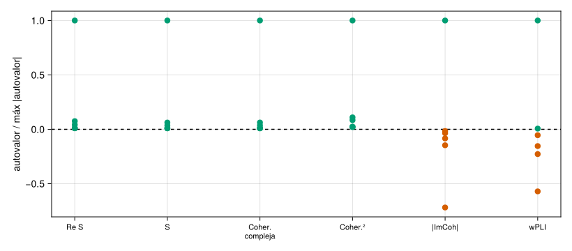

Figura 2.1: Autovalores (normalizados por el mayor en valor absoluto) de las seis matrices del experimento. Las cuatro primeras están en el semieje positivo; la coherencia imaginaria y el wPLI tienen autovalores negativos (Proposición 2.3).

```julia
colores = Makie.wong_colors()
fig = Figure(size = (820, 360))
ax = Axis(fig[1, 1]; xticks = (1:6, ["Re S", "S", "Coher.\ncompleja", "Coher.²", "|ImCoh|", "wPLI"]),
          ylabel = "autovalor / máx |autovalor|", xticklabelsize = 11)
hlines!(ax, [0.0]; color = :black, linestyle = :dash)
for (k, λ) in enumerate(autovalores)
    scatter!(ax, fill(k, length(λ)), λ ./ maximum(abs, λ); color = [x < 0 ? colores[6] : colores[3] for x in λ], markersize = 12)
end
fig
```

La Figura 2.1 es el resultado central del capítulo: las cuatro primeras matrices viven en el cono (HPD o SPD) y las dos últimas, no, y no por un fallo de estimación sino porque tienen **diagonal nula** (Proposición 2.3). Verificado numéricamente

### 2.3.1 Qué le ocurre a la matriz antes de verla

Antes del análisis, la señal sufre tres transformaciones lineales: la **ganancia** de cada electrodo (una matriz diagonal invertible $D$), la **mezcla** por conducción de volumen (una matriz invertible $M$) y la **referencia** (con $n$ canales, la referencia promedio es la proyección singular $H=I-\tfrac1n\mathbf 1\mathbf 1^\top$). Actúan sobre la covarianza como $P\mapsto DPD$, $P\mapsto MPM^\top$ y $P\mapsto HPH$.

**Proposición 2.4 (La referencia promedio saca la matriz del cono)** Si $P\in\R^{n\times n}$ y $H=I-\tfrac1n\mathbf 1\mathbf 1^\top$, entonces $HPH$ tiene $\mathbf 1$ en su núcleo y, por tanto, rango a lo sumo $n-1$: no es definida positiva. Demostrado

*Demostración*. $H\mathbf 1=\mathbf 1-\tfrac1n\mathbf 1(\mathbf 1^\top\mathbf 1)=0$, así que $(HPH)\mathbf 1=HPH\mathbf 1=0$.

En cambio, $D$ y $M$ son invertibles y $DPD$, $MPM^\top$ siguen en el cono. La celda siguiente lo comprueba con la covarianza de banda del experimento:

**Código**

```julia
P = Symmetric(real.(S))
n = size(P, 1)
D = Diagonal(exp.(0.5 .* randn(rng, n)))            # ganancias de electrodo
M = randn(rng, n, n) + 3I                           # mezcla invertible
H = I - ones(n, n) / n                              # referencia promedio
println("| Transformación | Rango | ¿Definida positiva? |\n|---|---|---|")
for (nombre, X) in (("Ninguna", P), ("Ganancias D P D", D * P * D), ("Mezcla M P Mᵀ", M * P * M'),
                    ("Referencia promedio H P H", H * P * H))
    println("| ", nombre, " | ", rank(Symmetric(X); rtol = 1e-10), " | ", isspd(Symmetric(X)) ? "sí" : "no", " |")
end
```

| Transformación | Rango | ¿Definida positiva? |
| --- | --- | --- |
| Ninguna | 6 | sí |
| Ganancias D P D | 6 | sí |
| Mezcla M P Mᵀ | 6 | sí |
| Referencia promedio H P H | 5 | no |

Las ganancias y la mezcla conservan el cono; la referencia promedio lo abandona. Cómo tratar ese caso (reducir a $n-1$ canales o regularizar) es el tema del capítulo 3.

### 2.3.2 Una invariancia útil: la correlación

**Proposición 2.5 (La correlación elimina las ganancias diagonales)** Sea $P\in\SPD_n$, $D$ diagonal con entradas positivas y $\operatorname{Corr}(P)_{ij}=P_{ij}/\sqrt{P_{ii}P_{jj}}$. Entonces $\operatorname{Corr}(DPD)=\operatorname{Corr}(P)$. Demostrado

*Demostración*. $(DPD)_{ij}=d_iP_{ij}d_j$ y $(DPD)_{ii}=d_i^2P_{ii}$, de modo que $\operatorname{Corr}(DPD)_{ij}=\dfrac{d_id_jP_{ij}}{\sqrt{d_i^2P_{ii}\,d_j^2P_{jj}}}=\operatorname{Corr}(P)_{ij}$, porque $d_i,d_j>0$ se cancelan.

Esa invariancia tiene un coste: la correlación descarta la **potencia** de cada canal, que es información fisiológica. Cuándo conviene pagarlo es una pregunta de la introducción y de los capítulos 4 y 6.

## 2.4 Experimento 2: conducción de volumen frente a acoplamiento con retardo

Dos sensores reciben la actividad de tres fuentes; las medidas de fase deben distinguir un acoplamiento real de una simple mezcla. El resultado teórico es sencillo.

**Proposición 2.6 (La parte imaginaria ignora una mezcla instantánea real)** Sea $Z=MY$ con $M\in\R^{n\times m}$ real y $Y\in\mathbb C^{m\times K}$. Entonces $\hat S_Z=M\hat S_YM^\top$ y $\operatorname{Im}\hat S_Z=M\,(\operatorname{Im}\hat S_Y)\,M^\top$. En particular, si $\operatorname{Im}\hat S_Y=0$ (fuentes sin relación de fase), $\operatorname{Im}\hat S_Z=0$. Demostrado

*Demostración*. $\hat S_Z=\tfrac1K MYY^*M^\top=M\hat S_YM^\top$ porque $M$ es real, y tomar la parte imaginaria conmuta con la multiplicación por matrices reales.

Es la razón de ser de la coherencia imaginaria (Nolte et al. 2004) y del wPLI (Vinck et al. 2011): la conducción de volumen, que es una mezcla instantánea real, no genera parte imaginaria; un **retardo** sí. Lo comprobamos sobre dos escenarios: solo conducción de volumen (sin acoplamiento entre las fuentes) y acoplamiento con retardo $\varphi=\pi/3$.

**Código**

```julia
rng2 = StableRNG(20261108)
A2 = MEZCLA[1:2, :]
escenarios = [("Solo volumen (κ = 0)", 0.0, 0.0), ("Retardo (κ = 0,6, φ = π/3)", 0.6, π / 3)]
nubes = Dict{String, Vector{ComplexF64}}()
println("| Escenario | Coherencia | Coherencia imaginaria | PLV | wPLI |\n|---|---|---|---|---|")
for (nombre, κ, φ) in escenarios
    Y = fuentes(rng2, 300; κ = κ, φ = φ)
    Z2 = sensores(rng2, Y; A = A2)
    nubes[nombre] = Z2[1, :] .* conj.(Z2[2, :])
    m = medidas(Z2[1, :], Z2[2, :])
    println("| ", nombre, " | ", join((round(v; digits = 3) for v in m), " | "), " |")
end
# comprobación numérica de la proposición con 6 sensores y sin ruido
Y = fuentes(rng2, 500)
println("\nIdentidad Im(M S_Y Mᵀ) = M Im(S_Y) Mᵀ: error relativo ",
        round(norm(imag(espectral(MEZCLA * Y)) - MEZCLA * imag(espectral(Y)) * MEZCLA') / norm(imag(espectral(MEZCLA * Y))); sigdigits = 2), ".")
```

| Escenario | Coherencia | Coherencia imaginaria | PLV | wPLI |
| --- | --- | --- | --- | --- |
| Solo volumen (κ = 0) | 0.903 | 0.001 | 0.854 | 0.004 |
| Retardo (κ = 0,6, φ = π/3) | 0.936 | 0.072 | 0.881 | 0.371 |

Identidad Im(M S_Y Mᵀ) = M Im(S_Y) Mᵀ: error relativo 2.2e-16.

**Código**

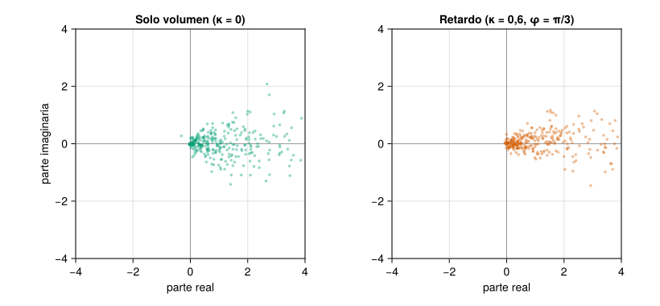

Figura 2.2: Espectro cruzado por segmento $X^{12}_k=Z_{k,1}\overline{Z_{k,2}}$ de los dos sensores en el plano complejo, normalizado por su mediana. Con solo conducción de volumen la nube queda simétrica respecto del eje real (la parte imaginaria promedia cero); con retardo la parte imaginaria deja de promediar cero (véanse las medidas de la tabla anterior).

```julia
fig = Figure(size = (820, 380))
for (j, (nombre, _, _)) in enumerate(escenarios)
    x = nubes[nombre]; s = sort(abs.(x))[length(x) ÷ 2]
    ax = Axis(fig[1, j]; title = nombre, aspect = DataAspect(), xlabel = "parte real", ylabel = j == 1 ? "parte imaginaria" : "")
    hlines!(ax, [0.0]; color = :gray, linewidth = 0.8); vlines!(ax, [0.0]; color = :gray, linewidth = 0.8)
    scatter!(ax, real.(x) ./ s, imag.(x) ./ s; color = (colores[j == 1 ? 3 : 6], 0.4), markersize = 5)
    xlims!(ax, -4, 4); ylims!(ax, -4, 4)
end
fig
```

En el primer escenario la coherencia y el PLV son altos, porque los sensores comparten una fuente, pero la coherencia imaginaria es casi nula y el wPLI es pequeño: la medida «ve» que no hay retardo. En el segundo, la parte imaginaria aparece y el wPLI sube Verificado numéricamente. Con pocos segmentos el wPLI de dos señales sin relación de fase no es exactamente cero sino algo positivo (es un valor absoluto de una media ruidosa); de ahí el interés por estimadores corregidos del sesgo (Vinck et al. 2011).

## 2.5 Lo que esto no demuestra

- **No demuestra que una geometría sea mejor que otra.** Clasifica las matrices por su tipo; qué geometría compara mejor cada una es la pregunta de los capítulos siguientes.
- **El modelo sintético es mínimo.** Una frecuencia, tres fuentes, mezcla instantánea real y ruido de sensor: sirve para ilustrar proposiciones, no para reproducir un EEG. Lo que se observa en las figuras vale para ese generador Hipótesis sintética.
- **La conducción de volumen real no es siempre instantánea ni estacionaria.** La Proposición 2.6 es exacta para una mezcla real instantánea; con retardos de propagación o mezclas que varían, aparece parte imaginaria espuria.
- **La covarianza de banda definida aquí** depende de la normalización de la ventana, y su identificación con la covarianza de la señal filtrada queda por verificar con su fuente.
- **Las medidas de conectividad se han definido por pares.** Cómo se construyen matrices completas a partir de ellas, y si son semidefinidas (PLV), se discute en el capítulo 7.

## 2.6 Autoevaluación

**Tip¿Puede ser definida positiva una matriz de wPLI?**

Una matriz de wPLI tiene diagonal nula por convención y entradas en $[0,1]$. ¿Puede ser definida positiva?

**Respuesta.** No: tiene traza cero y no es la matriz nula, así que tiene autovalores de los dos signos (Proposición 2.3). Sumarle un múltiplo de la identidad la haría definida positiva, pero eso cambia la matriz y sus distancias (capítulo 7).

**TipParte real definida positiva, matriz singular**

Si $\operatorname{Re}S$ es definida positiva, ¿lo es $S$?

**Respuesta.** No necesariamente: $S=\begin{pmatrix}1&i\\-i&1\end{pmatrix}$ es singular y su parte real es la identidad (Proposición 2.1). El recíproco sí es cierto.

**TipDos sensores, una fuente común**

Dos sensores registran la misma fuente mezclada con pesos distintos y reales, y no hay más actividad. ¿Qué vale la coherencia imaginaria esperada?

**Respuesta.** Cero: con una sola fuente real mezclada, $\operatorname{Im}S_Y=0$ y $\operatorname{Im}S_Z=M\,\operatorname{Im}S_Y\,M^\top=0$ (Proposición 2.6). La coherencia no será cero, y por eso la coherencia sola no basta para detectar acoplamiento.

## 2.7 Ejercicios

**Ejercicio 2.1** Demuestra que si $K<n$ la matriz $\hat S(f)$ de la ecuación 2.1 es singular y que, con $K\ge n$, es definida positiva con probabilidad uno cuando los $X_k$ son gaussianos complejos circulares independientes con covarianza definida positiva.

**TipPista**

El rango de $\hat S$ es el de la matriz $n\times K$ de columnas $X_k$.

**Ejercicio 2.2** Calcula, para $\hat C=\begin{pmatrix}1&0{,}5i\\-0{,}5i&1\end{pmatrix}$, la matriz $\big(|\hat C_{ij}|^2\big)$ y sus autovalores, y comprueba la Proposición 2.2.

**Ejercicio 2.3** Sea $W=\begin{pmatrix}0&a&b\\a&0&c\\b&c&0\end{pmatrix}$ con $a,b,c>0$. Calcula $\operatorname{tr}W$ y $\det W$ y deduce cuántos autovalores positivos y cuántos negativos tiene.

**NotaSolución**

$\operatorname{tr}W=0$ y $\det W=2abc>0$. El producto de los tres autovalores es positivo y su suma es cero, así que no pueden ser los tres positivos ni los tres negativos: hay uno positivo y dos negativos (un producto positivo exige un número par de negativos, y al menos uno es negativo porque la suma es cero).

**Ejercicio 2.4** Sean $X_1,\dots,X_K\in\R^{n\times T}$ segmentos con media nula por canal y $P_k=\tfrac1TX_kX_k^\top$. Demuestra que la covarianza, con normalización $1/(KT)$, del registro concatenado $[X_1\ \cdots\ X_K]$ es la media aritmética $\tfrac1K\sum_kP_k$. ¿Qué pregunta responde entonces la media euclídea de covarianzas, y cuál la media geométrica de la Proposición 4.5?

**NotaSolución**

El registro concatenado $X=[X_1\ \cdots\ X_K]$ tiene media nula por canal, porque la tiene cada segmento, y $XX^\top=\sum_kX_kX_k^\top$. Por tanto $\tfrac1{KT}XX^\top=\tfrac1K\sum_k\tfrac1TX_kX_k^\top=\tfrac1K\sum_kP_k$. La media aritmética es la covarianza de todos los datos juntos: la respuesta correcta si los segmentos son muestras de un mismo proceso. La media geométrica no es la covarianza de ningún registro agregado; es el centro de los segmentos para la geometría afín-invariante, insensible a una mezcla lineal común.

**Ejercicio 2.5** (Laboratorio) Con `NeuroRiemann.jl`, comprueba que `isspd` rechaza la covarianza con referencia promedio $HPH^\top$ y acepta la de $n-1$ canales obtenida eliminando uno de los canales. ¿Qué rango tiene cada una?

**Ejercicio 2.6** Con las funciones `fuentes`, `sensores` y `medidas` del laboratorio, estima con 500 repeticiones el wPLI medio de dos sensores sin acoplamiento ($\kappa=0$) para $K\in\{5,20,80,320\}$. ¿Cómo depende del número de segmentos y por qué no es cero?

Bhatia, Rajendra. 2007. *Positive Definite Matrices*. Princeton Series en Applied Mathematics. Princeton University Press.

Nolte, Guido, Ou Bai, Lewis Wheaton, Zoltan Mari, Sherry Vorbach, y Mark Hallett. 2004. «Identifying true brain interaction from EEG data using the imaginary part of coherency». *Clinical Neurophysiology* 115 (10): 2292-307. https://doi.org/10.1016/j.clinph.2004.04.029.

Vinck, Martin, Robert Oostenveld, Marijn van Wingerden, Francesco Battaglia, y Cyriel M. A. Pennartz. 2011. «An improved index of phase-synchronization for electrophysiological data in the presence of volume-conduction, noise and sample-size bias». *NeuroImage* 55 (4): 1548-65. https://doi.org/10.1016/j.neuroimage.2011.01.055.